# Project: Airlines Delay and Cancellation Analysis

- Introduction
- Data Wrangling
- Data Cleaning
- Exploratory Data Analysis
- Conclusions

## Introduction

### Dataset Description

> This dataset reports flights in the United States, including carriers, arrival and departure delays, and reasons for delays. The goal of this project is to summarize the data by time periods, carriers,airports and understand different factors causing the airline delays and cancellation.

## Data Wrangling

```python
## Import all necessary packages:

import pandas as pd
import numpy as np
import matplotlib.pyplot as plt
import seaborn as sns

# display all columns
pd.set_option('display.max_columns', 500)

# use style
plt.style.use('seaborn-dark')
```

```python
# loading the data and read the first five rows
airlines = pd.read_csv('flight_2008.csv')
carrier = pd.read_csv('carriers.csv')
airlines.head()
```

|  | Year | Month | DayofMonth | DayOfWeek | DepTime | CRSDepTime | ArrTime | CRSArrTime | UniqueCarrier | FlightNum | TailNum | ActualElapsedTime | CRSElapsedTime | AirTime | ArrDelay | DepDelay | Origin | Dest | Distance | TaxiIn | TaxiOut | Cancelled | CancellationCode | Diverted | CarrierDelay | WeatherDelay | NASDelay | SecurityDelay | LateAircraftDelay |
| --- | --- | --- | --- | --- | --- | --- | --- | --- | --- | --- | --- | --- | --- | --- | --- | --- | --- | --- | --- | --- | --- | --- | --- | --- | --- | --- | --- | --- | --- |
| 0 | 2008 | 1 | 3 | 4 | 2003.0 | 1955 | 2211.0 | 2225 | WN | 335 | N712SW | 128.0 | 150.0 | 116.0 | -14.0 | 8.0 | IAD | TPA | 810 | 4.0 | 8.0 | 0 | NaN | 0 | NaN | NaN | NaN | NaN | NaN |
| 1 | 2008 | 1 | 3 | 4 | 754.0 | 735 | 1002.0 | 1000 | WN | 3231 | N772SW | 128.0 | 145.0 | 113.0 | 2.0 | 19.0 | IAD | TPA | 810 | 5.0 | 10.0 | 0 | NaN | 0 | NaN | NaN | NaN | NaN | NaN |
| 2 | 2008 | 1 | 3 | 4 | 628.0 | 620 | 804.0 | 750 | WN | 448 | N428WN | 96.0 | 90.0 | 76.0 | 14.0 | 8.0 | IND | BWI | 515 | 3.0 | 17.0 | 0 | NaN | 0 | NaN | NaN | NaN | NaN | NaN |
| 3 | 2008 | 1 | 3 | 4 | 926.0 | 930 | 1054.0 | 1100 | WN | 1746 | N612SW | 88.0 | 90.0 | 78.0 | -6.0 | -4.0 | IND | BWI | 515 | 3.0 | 7.0 | 0 | NaN | 0 | NaN | NaN | NaN | NaN | NaN |
| 4 | 2008 | 1 | 3 | 4 | 1829.0 | 1755 | 1959.0 | 1925 | WN | 3920 | N464WN | 90.0 | 90.0 | 77.0 | 34.0 | 34.0 | IND | BWI | 515 | 3.0 | 10.0 | 0 | NaN | 0 | 2.0 | 0.0 | 0.0 | 0.0 | 32.0 |

```python
# exploring the shape of the dataset
airlines.shape
```

```
(7009728, 29)
```

```python
# exploring the columns and dtypes:
airlines.info(verbose=True, show_counts=True)
```

```
<class 'pandas.core.frame.DataFrame'>
RangeIndex: 7009728 entries, 0 to 7009727
Data columns (total 29 columns):
 #   Column             Non-Null Count    Dtype
---  ------             --------------    -----
 0   Year               7009728 non-null  int64
 1   Month              7009728 non-null  int64
 2   DayofMonth         7009728 non-null  int64
 3   DayOfWeek          7009728 non-null  int64
 4   DepTime            6873482 non-null  float64
 5   CRSDepTime         7009728 non-null  int64
 6   ArrTime            6858079 non-null  float64
 7   CRSArrTime         7009728 non-null  int64
 8   UniqueCarrier      7009728 non-null  object
 9   FlightNum          7009728 non-null  int64
```

[output cut: 21 more lines]

```python
# the number of unique values in each column:
airlines.nunique()
```

```
Year                    1
Month                  12
DayofMonth             31
DayOfWeek               7
DepTime              1440
CRSDepTime           1217
ArrTime              1440
CRSArrTime           1378
UniqueCarrier          20
FlightNum            7539
TailNum              5373
ActualElapsedTime     689
CRSElapsedTime        525
AirTime               663
ArrDelay             1153
DepDelay             1134
Origin                303
Dest                  304
Distance             1435
TaxiIn                190
TaxiOut               342
Cancelled               2
CancellationCode        4
Diverted                2
CarrierDelay          984
WeatherDelay          599
NASDelay              574
SecurityDelay         156
LateAircraftDelay     564
dtype: int64
```

## Data Cleaning

```python
# convert the numeric values in Cancelled column to categorical (cancelled - not cancelled):

airlines['Cancelled'] = airlines['Cancelled'].replace([1, 0], ['Cancelled', 'Not Cancelled'])
```

```python
# convert the numeric values in Diverted column to categorical (converted - not converted):
airlines['Diverted'] = airlines['Diverted'].replace([1,0], ['Diverted', 'Not Diverted'])
```

```python
airlines.head()
```

|  | Year | Month | DayofMonth | DayOfWeek | DepTime | CRSDepTime | ArrTime | CRSArrTime | UniqueCarrier | FlightNum | TailNum | ActualElapsedTime | CRSElapsedTime | AirTime | ArrDelay | DepDelay | Origin | Dest | Distance | TaxiIn | TaxiOut | Cancelled | CancellationCode | Diverted | CarrierDelay | WeatherDelay | NASDelay | SecurityDelay | LateAircraftDelay |
| --- | --- | --- | --- | --- | --- | --- | --- | --- | --- | --- | --- | --- | --- | --- | --- | --- | --- | --- | --- | --- | --- | --- | --- | --- | --- | --- | --- | --- | --- |
| 0 | 2008 | 1 | 3 | 4 | 2003.0 | 1955 | 2211.0 | 2225 | WN | 335 | N712SW | 128.0 | 150.0 | 116.0 | -14.0 | 8.0 | IAD | TPA | 810 | 4.0 | 8.0 | Not Cancelled | NaN | Not Diverted | NaN | NaN | NaN | NaN | NaN |
| 1 | 2008 | 1 | 3 | 4 | 754.0 | 735 | 1002.0 | 1000 | WN | 3231 | N772SW | 128.0 | 145.0 | 113.0 | 2.0 | 19.0 | IAD | TPA | 810 | 5.0 | 10.0 | Not Cancelled | NaN | Not Diverted | NaN | NaN | NaN | NaN | NaN |
| 2 | 2008 | 1 | 3 | 4 | 628.0 | 620 | 804.0 | 750 | WN | 448 | N428WN | 96.0 | 90.0 | 76.0 | 14.0 | 8.0 | IND | BWI | 515 | 3.0 | 17.0 | Not Cancelled | NaN | Not Diverted | NaN | NaN | NaN | NaN | NaN |
| 3 | 2008 | 1 | 3 | 4 | 926.0 | 930 | 1054.0 | 1100 | WN | 1746 | N612SW | 88.0 | 90.0 | 78.0 | -6.0 | -4.0 | IND | BWI | 515 | 3.0 | 7.0 | Not Cancelled | NaN | Not Diverted | NaN | NaN | NaN | NaN | NaN |
| 4 | 2008 | 1 | 3 | 4 | 1829.0 | 1755 | 1959.0 | 1925 | WN | 3920 | N464WN | 90.0 | 90.0 | 77.0 | 34.0 | 34.0 | IND | BWI | 515 | 3.0 | 10.0 | Not Cancelled | NaN | Not Diverted | 2.0 | 0.0 | 0.0 | 0.0 | 32.0 |

```python
# the dtype of all columns
airlines.dtypes
```

```
Year                   int64
Month                  int64
DayofMonth             int64
DayOfWeek              int64
DepTime              float64
CRSDepTime             int64
ArrTime              float64
CRSArrTime             int64
UniqueCarrier         object
FlightNum              int64
TailNum               object
ActualElapsedTime    float64
CRSElapsedTime       float64
AirTime              float64
ArrDelay             float64
DepDelay             float64
Origin                object
Dest                  object
Distance               int64
TaxiIn               float64
TaxiOut              float64
Cancelled             object
CancellationCode      object
Diverted              object
CarrierDelay         float64
WeatherDelay         float64
NASDelay             float64
SecurityDelay        float64
LateAircraftDelay    float64
dtype: object
```

#### Renaming some columns

```python
# first lets replace uppercase to lowercase
airlines.rename(columns=lambda x: x.strip().lower(), inplace=True)
```

```python
# second lets fix and put underscore in some columns

rename_column = { 'deptime' : 'departure_time', 'crsdeptime' : 'scheduled_deptime',
                 'arrtime' : 'arrival_time', 'crsarrtime' : 'scheduled_arrtime',
                 'uniquecarrier' : 'unique_carrier', 'flightnum' : 'flight_num',
                 'tailnum' : 'tail_num', 'actualelapsedtime' : 'actual_elapsed_time',
                 'crselapsedtime' : 'scheduled_elapsed_time', 'airtime' : 'air_time',
                 'arrdelay' : 'arrival_delay', 'depdelay' : 'departure_delay',
                 'taxiin' : 'taxi_in', 'taxiout' : 'taxi_out', 'cancellationcode' : 'cancellation_code',
                 'carrierdelay' : 'carrier_delay', 'weatherdelay' : 'weather_delay',
                 'nasdelay' :'NAS_delay', 'securitydelay' : 'security_delay',
                 'lateaircraftdelay' : 'late_aircraft_delay'}

airlines.rename(columns=rename_column, inplace=True)
```

```python
airlines.head(3)
```

|  | year | month | dayofmonth | dayofweek | departure_time | scheduled_deptime | arrival_time | scheduled_arrtime | unique_carrier | flight_num | tail_num | actual_elapsed_time | scheduled_elapsed_time | air_time | arrival_delay | departure_delay | origin | dest | distance | taxi_in | taxi_out | cancelled | cancellation_code | diverted | carrier_delay | weather_delay | NAS_delay | security_delay | late_aircraft_delay |
| --- | --- | --- | --- | --- | --- | --- | --- | --- | --- | --- | --- | --- | --- | --- | --- | --- | --- | --- | --- | --- | --- | --- | --- | --- | --- | --- | --- | --- | --- |
| 0 | 2008 | 1 | 3 | 4 | 2003.0 | 1955 | 2211.0 | 2225 | WN | 335 | N712SW | 128.0 | 150.0 | 116.0 | -14.0 | 8.0 | IAD | TPA | 810 | 4.0 | 8.0 | Not Cancelled | NaN | Not Diverted | NaN | NaN | NaN | NaN | NaN |
| 1 | 2008 | 1 | 3 | 4 | 754.0 | 735 | 1002.0 | 1000 | WN | 3231 | N772SW | 128.0 | 145.0 | 113.0 | 2.0 | 19.0 | IAD | TPA | 810 | 5.0 | 10.0 | Not Cancelled | NaN | Not Diverted | NaN | NaN | NaN | NaN | NaN |
| 2 | 2008 | 1 | 3 | 4 | 628.0 | 620 | 804.0 | 750 | WN | 448 | N428WN | 96.0 | 90.0 | 76.0 | 14.0 | 8.0 | IND | BWI | 515 | 3.0 | 17.0 | Not Cancelled | NaN | Not Diverted | NaN | NaN | NaN | NaN | NaN |

```python
# Creating a copy of the original data :
df = airlines.copy()
```

```python
# add full date column
df['full_date'] = pd.to_datetime(dict(year=df.year, month=df.month, day=df.dayofmonth))
```

```python
df['month_name'] = pd.to_datetime(df['full_date']).dt.month_name()
df['day_name'] = pd.to_datetime(df['full_date']).dt.day_name()
```

```python
# checking for duplicates:
df.duplicated().sum()
```

```
4
```

```python
# drop the duplicated:
duplicated = df.drop_duplicates()
```

#### Check for missing values

```python
df.isnull().sum()
```

```
year                            0
month                           0
dayofmonth                      0
dayofweek                       0
departure_time             136246
scheduled_deptime               0
arrival_time               151649
scheduled_arrtime               0
unique_carrier                  0
flight_num                      0
tail_num                    83365
actual_elapsed_time        154699
scheduled_elapsed_time        844
air_time                   154699
arrival_delay              154699
departure_delay            136246
origin                          0
dest                            0
distance                        0
taxi_in                    151649
taxi_out                   137058
cancelled                       0
cancellation_code         6872294
diverted                        0
carrier_delay             5484993
weather_delay             5484993
NAS_delay                 5484993
security_delay            5484993
late_aircraft_delay       5484993
full_date                       0
month_name                      0
day_name                        0
dtype: int64
```

#### Using interpolation to fill NAN values :

> interpolation is used to fill missing values with previous one or two values. and I am going to use it with all columns that have (minutes) values.

```python
df['departure_time'] = df['departure_time'].interpolate(method='linear', limit_direction='both', axis=0)
df['arrival_time'] = df['arrival_time'].interpolate(method='linear', limit_direction='both', axis=0)

df['actual_elapsed_time'] = df['actual_elapsed_time'].interpolate(method='linear', limit_direction='both', axis=0)
df['scheduled_elapsed_time'] = df['scheduled_elapsed_time'].interpolate(method='linear', limit_direction='both', axis=0)

df['air_time'] = df['air_time'].interpolate(method='linear', limit_direction='both', axis=0)
df['arrival_delay'] = df['arrival_delay'].interpolate(method='linear', limit_direction='both', axis=0)

df['departure_delay'] = df['departure_delay'].interpolate(method='linear', limit_direction='both', axis=0)
df['taxi_in'] = df['taxi_in'].interpolate(method='linear', limit_direction='both', axis=0)

df['taxi_out'] = df['taxi_out'].interpolate(method='linear', limit_direction='both', axis=0)
df['carrier_delay'] = df['carrier_delay'].interpolate(method='linear', limit_direction='both', axis=0)

df['weather_delay'] = df['weather_delay'].interpolate(method='linear', limit_direction='both', axis=0)
df['NAS_delay'] = df['NAS_delay'].interpolate(method='linear', limit_direction='both', axis=0)

df['security_delay'] = df['security_delay'].interpolate(method='linear', limit_direction='both', axis=0)
df['late_aircraft_delay'] = df['late_aircraft_delay'].interpolate(method='linear', limit_direction='both', axis=0)
```

```python
# checked for missing values after fill it with interpolation method
df.isnull().sum()
```

```
year                            0
month                           0
dayofmonth                      0
dayofweek                       0
departure_time                  0
scheduled_deptime               0
arrival_time                    0
scheduled_arrtime               0
unique_carrier                  0
flight_num                      0
tail_num                    83365
actual_elapsed_time             0
scheduled_elapsed_time          0
air_time                        0
arrival_delay                   0
departure_delay                 0
origin                          0
dest                            0
distance                        0
taxi_in                         0
taxi_out                        0
cancelled                       0
cancellation_code         6872294
diverted                        0
carrier_delay                   0
weather_delay                   0
NAS_delay                       0
security_delay                  0
late_aircraft_delay             0
full_date                       0
month_name                      0
day_name                        0
dtype: int64
```

```python
# Creating & setting a customized palette:
custom_palette = ['#118ab2', '#ef476f', '#06d6a0', '#ffd166', '#073b4c']
sns.set_palette(custom_palette)

# Defining our main colors:
blue = custom_palette[0]
red = custom_palette[1]
green = custom_palette[2]
```

# Exploratory Data Analysis

## Univariate Exploration

> In univariate analysis, there is only one dependable variable in a dataset, it explores each variable separately. It is possible for two kinds of variables- Categorical and Numerical.

### First : Univariate Distribution of Numerical Variables

```python
# we will work on sample for quick render and results
samples = np.random.choice(df.shape[0], 200000, replace=False)
airline_samp = df.loc[samples, :]
```

```python
airline_cancelled = airline_samp.query("cancelled == 'Cancelled'")
airline_notcancelled = airline_samp.query("cancelled == 'Not Cancelled'")
```

#### lets see the distrbution of distance with airlines that are Not cancelled

```python
airline_notcancelled['distance'].describe()
```

```
count    195971.000000
mean        729.409183
std         564.327850
min          24.000000
25%         328.000000
50%         583.000000
75%         954.000000
max        4962.000000
Name: distance, dtype: float64
```

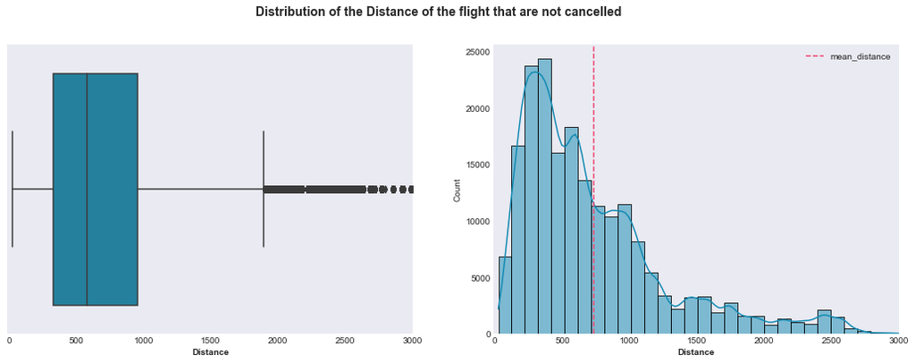

```python
# create subplot
fig, (ax1, ax2) = plt.subplots(ncols=2, figsize=[18, 6])

# box plot
a = sns.boxplot(data = airline_notcancelled , x = 'distance', color = blue, ax = ax1)
a.set_xlabel(xlabel= 'Distance', size = 10, weight = 'bold')
a.set(xlim=(-10, 3000))

# histogram
a = sns.histplot(data = airline_notcancelled, x = 'distance', kde = True, bins= 50, color = blue, ax = ax2)
a.set_xlabel(xlabel = 'Distance' , size = 10, weight = 'bold')
a.set(xlim=(-10, 3000))

# draw mean distance line in the histogram plot
mean = airline_notcancelled.distance.mean()
plt.axvline(x = mean, color = red, linestyle = '--', label = 'mean_distance')

# add title
plt.suptitle("Distribution of the Distance of the flight that are not cancelled", weight='bold', size=14)

plt.legend()
plt.show()
```

- The histogram is skewied to the right with mean distance around 750 miles.
- The most flights that are not cancelled is less than 1000 miles in distance.

#### lets see the distrbution of distance with airlines that are cancelled

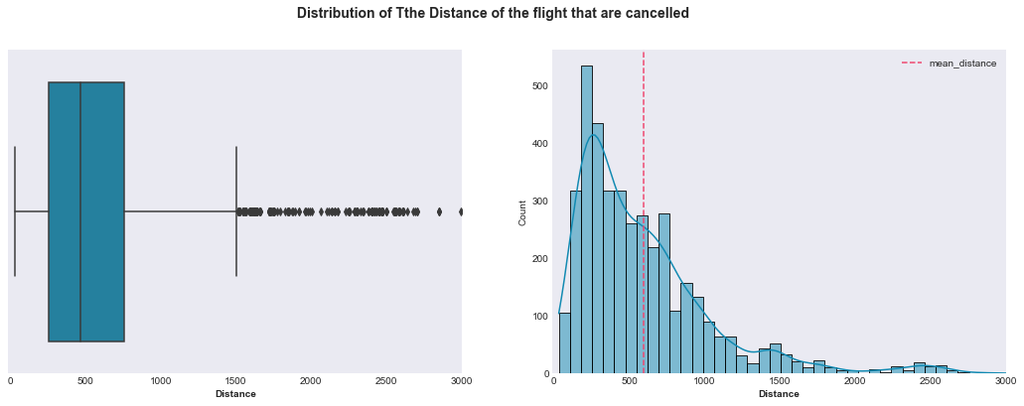

```python
# create subplot
fig, (ax1, ax2) = plt.subplots(ncols=2, figsize=[18, 6])

# box plot
a = sns.boxplot(data = airline_cancelled , x = 'distance', color = blue, ax = ax1)
a.set_xlabel(xlabel= 'Distance', size = 10, weight = 'bold')
a.set(xlim=(-10, 3000))

# histogram
a = sns.histplot(data = airline_cancelled, x = 'distance', kde = True, bins= 50, color = blue, ax = ax2)
a.set_xlabel(xlabel = 'Distance' , size = 10, weight = 'bold')
a.set(xlim=(-10, 3000))

# draw mean distance line in the histogram plot
mean2 = airline_cancelled.distance.mean()
plt.axvline(x = mean2, color = red, linestyle = '--', label = 'mean_distance')

# add title
plt.suptitle(" Distribution of Tthe Distance of the flight that are cancelled", weight='bold', size=14)

plt.legend()
plt.show()
```

### second : Univariate Distribution of Categorical Variables

```python
df.head()
```

|  | year | month | dayofmonth | dayofweek | departure_time | scheduled_deptime | arrival_time | scheduled_arrtime | unique_carrier | flight_num | tail_num | actual_elapsed_time | scheduled_elapsed_time | air_time | arrival_delay | departure_delay | origin | dest | distance | taxi_in | taxi_out | cancelled | cancellation_code | diverted | carrier_delay | weather_delay | NAS_delay | security_delay | late_aircraft_delay | … |
| --- | --- | --- | --- | --- | --- | --- | --- | --- | --- | --- | --- | --- | --- | --- | --- | --- | --- | --- | --- | --- | --- | --- | --- | --- | --- | --- | --- | --- | --- | --- |
| 0 | 2008 | 1 | 3 | 4 | 2003.0 | 1955 | 2211.0 | 2225 | WN | 335 | N712SW | 128.0 | 150.0 | 116.0 | -14.0 | 8.0 | IAD | TPA | 810 | 4.0 | 8.0 | Not Cancelled | NaN | Not Diverted | 2.0 | 0.0 | 0.0 | 0.0 | 32.0 | … |
| 1 | 2008 | 1 | 3 | 4 | 754.0 | 735 | 1002.0 | 1000 | WN | 3231 | N772SW | 128.0 | 145.0 | 113.0 | 2.0 | 19.0 | IAD | TPA | 810 | 5.0 | 10.0 | Not Cancelled | NaN | Not Diverted | 2.0 | 0.0 | 0.0 | 0.0 | 32.0 | … |
| 2 | 2008 | 1 | 3 | 4 | 628.0 | 620 | 804.0 | 750 | WN | 448 | N428WN | 96.0 | 90.0 | 76.0 | 14.0 | 8.0 | IND | BWI | 515 | 3.0 | 17.0 | Not Cancelled | NaN | Not Diverted | 2.0 | 0.0 | 0.0 | 0.0 | 32.0 | … |
| 3 | 2008 | 1 | 3 | 4 | 926.0 | 930 | 1054.0 | 1100 | WN | 1746 | N612SW | 88.0 | 90.0 | 78.0 | -6.0 | -4.0 | IND | BWI | 515 | 3.0 | 7.0 | Not Cancelled | NaN | Not Diverted | 2.0 | 0.0 | 0.0 | 0.0 | 32.0 | … |
| 4 | 2008 | 1 | 3 | 4 | 1829.0 | 1755 | 1959.0 | 1925 | WN | 3920 | N464WN | 90.0 | 90.0 | 77.0 | 34.0 | 34.0 | IND | BWI | 515 | 3.0 | 10.0 | Not Cancelled | NaN | Not Diverted | 2.0 | 0.0 | 0.0 | 0.0 | 32.0 | … |

#### Cancelled VS Not Cancelled and Diverted Vs Not Diverted :

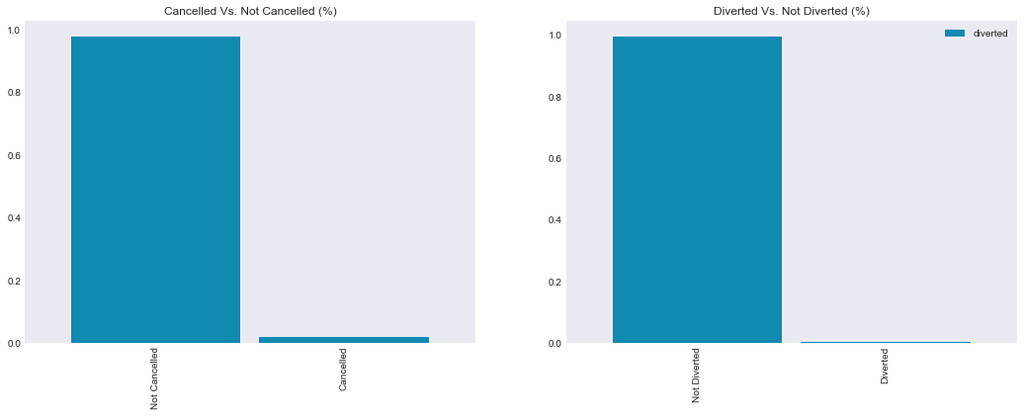

```python
fig, (ax1, ax2) = plt.subplots(ncols=2, figsize=(18, 6))

# first bar plot to cancelled and not cancelled
ax1.set_title('Cancelled Vs. Not Cancelled (%)')
airline_samp.cancelled.value_counts(normalize=True).plot.bar(color=blue, width=0.9, ax=ax1)

# second bar plot to Diverted and not Diverted
ax2.set_title('Diverted Vs. Not Diverted (%)')
p1= airline_samp.diverted.value_counts(normalize=True).plot.bar(color=blue, width=0.9, ax=ax2)


plt.legend()
plt.show()
```

> It seems that less than 5% of this data is cancelled, and almost zero is diverted.

```python
df.head()
```

|  | year | month | dayofmonth | dayofweek | departure_time | scheduled_deptime | arrival_time | scheduled_arrtime | unique_carrier | flight_num | tail_num | actual_elapsed_time | scheduled_elapsed_time | air_time | arrival_delay | departure_delay | origin | dest | distance | taxi_in | taxi_out | cancelled | cancellation_code | diverted | carrier_delay | weather_delay | NAS_delay | security_delay | late_aircraft_delay | … |
| --- | --- | --- | --- | --- | --- | --- | --- | --- | --- | --- | --- | --- | --- | --- | --- | --- | --- | --- | --- | --- | --- | --- | --- | --- | --- | --- | --- | --- | --- | --- |
| 0 | 2008 | 1 | 3 | 4 | 2003.0 | 1955 | 2211.0 | 2225 | WN | 335 | N712SW | 128.0 | 150.0 | 116.0 | -14.0 | 8.0 | IAD | TPA | 810 | 4.0 | 8.0 | Not Cancelled | NaN | Not Diverted | 2.0 | 0.0 | 0.0 | 0.0 | 32.0 | … |
| 1 | 2008 | 1 | 3 | 4 | 754.0 | 735 | 1002.0 | 1000 | WN | 3231 | N772SW | 128.0 | 145.0 | 113.0 | 2.0 | 19.0 | IAD | TPA | 810 | 5.0 | 10.0 | Not Cancelled | NaN | Not Diverted | 2.0 | 0.0 | 0.0 | 0.0 | 32.0 | … |
| 2 | 2008 | 1 | 3 | 4 | 628.0 | 620 | 804.0 | 750 | WN | 448 | N428WN | 96.0 | 90.0 | 76.0 | 14.0 | 8.0 | IND | BWI | 515 | 3.0 | 17.0 | Not Cancelled | NaN | Not Diverted | 2.0 | 0.0 | 0.0 | 0.0 | 32.0 | … |
| 3 | 2008 | 1 | 3 | 4 | 926.0 | 930 | 1054.0 | 1100 | WN | 1746 | N612SW | 88.0 | 90.0 | 78.0 | -6.0 | -4.0 | IND | BWI | 515 | 3.0 | 7.0 | Not Cancelled | NaN | Not Diverted | 2.0 | 0.0 | 0.0 | 0.0 | 32.0 | … |
| 4 | 2008 | 1 | 3 | 4 | 1829.0 | 1755 | 1959.0 | 1925 | WN | 3920 | N464WN | 90.0 | 90.0 | 77.0 | 34.0 | 34.0 | IND | BWI | 515 | 3.0 | 10.0 | Not Cancelled | NaN | Not Diverted | 2.0 | 0.0 | 0.0 | 0.0 | 32.0 | … |

#### What is the unique carrier that is cancelled most ?

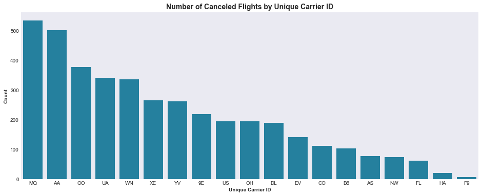

```python
plt.figure(figsize = (16,6))

order =  airline_cancelled.unique_carrier.value_counts().index
sns.countplot(data = airline_cancelled , x = 'unique_carrier', order = order , color = blue)

plt.xlabel('Unique Carrier ID', fontsize = 10, weight = "bold")
plt.ylabel('Count', fontsize = 10, weight = "bold")
plt.title('Number of Canceled Flights by Unique Carrier ID', fontsize = 14, weight = "bold")

plt.show()
```

```python
carrier.query("Code == 'MQ' or Code == 'AA'")
```

|  | Code | Description |
| --- | --- | --- |
| 100 | AA | American Airlines Inc. |
| 848 | MQ | American Eagle Airlines Inc. |

### lets see what is the most reason that make the cancellation happen ?

```python
airline_cancelled['cancellation_code'].value_counts()
```

```
B    1652
A    1585
C     792
Name: cancellation_code, dtype: int64
```

> The Cancellation Code : reason for cancellation (A = carrier, B = weather, C = NAS, D = security)

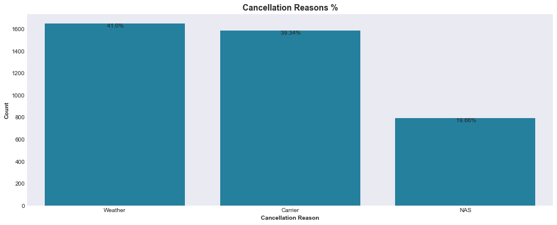

```python
plt.figure(figsize=[16, 6])

# Plot
order = airline_cancelled['cancellation_code'].value_counts().index
g = sns.countplot(data=airline_cancelled, x='cancellation_code', color=blue, order=order)

# writing the ration over the bars
for bar in range(airline_cancelled['cancellation_code'].value_counts().shape[0]):
    count = airline_cancelled['cancellation_code'].value_counts()[bar]
    pct = (airline_cancelled['cancellation_code'].value_counts()[bar]/\
    airline_cancelled['cancellation_code'].shape[0])
    pct = (round(pct, 5)*100).round(2)
    plt.text(x=bar, y=count, s= f" {pct}%", va='top', ha='center', fontsize = 10)


# rename the columns
g.set_xticklabels(['Weather', 'Carrier', 'NAS'])

# axes labels
plt.xlabel('Cancellation Reason', fontsize = 10, weight = "bold")
plt.ylabel('Count', fontsize = 10, weight = "bold")

# title
plt.title('Cancellation Reasons %', weight='bold', size=14)

plt.show()
```

> The most two reasons that affect the cancellation process are **Weather and Carrier** and then the National Air System. And the security dont have affect on the cancellation process

### Which month has more cancellation and what is the reason ?

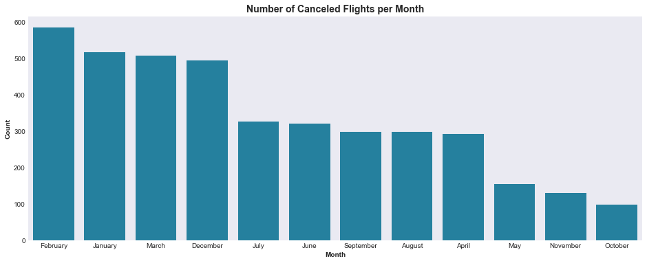

```python
plt.figure(figsize = (16,6))

# Plot
order = airline_cancelled['month_name'].value_counts().index
g = sns.countplot(data=airline_cancelled, x = 'month_name', color=blue, order=order)

# axes labels and title
plt.xlabel('Month', fontsize = 10, weight = "bold")
plt.ylabel('Count', fontsize = 10, weight = "bold")
plt.title('Number of Canceled Flights per Month', fontsize = 14, weight = "bold")

plt.show()
```

### Which day has the most cancelled flights on ?

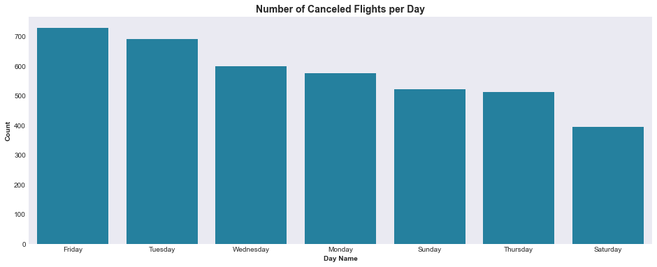

```python
plt.figure(figsize = (16,6))

# Plot
order = airline_cancelled.day_name.value_counts().index
g = sns.countplot(data=airline_cancelled, x = 'day_name', color=blue, order=order)

# axes labels and title
plt.xlabel('Day Name', fontsize = 10, weight = "bold")
plt.ylabel('Count', fontsize = 10, weight = "bold")
plt.title('Number of Canceled Flights per Day', fontsize = 14, weight = "bold")

plt.show()
```

> The most flights cancelled happen in Friday and Tuesday.

### Which day of month has the most flights cancelled ?

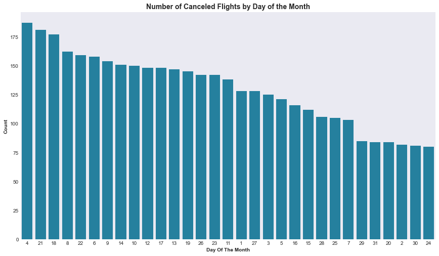

```python
# DayofMonth
plt.figure(figsize=[14.70, 8.27])

# get order
order = airline_cancelled['dayofmonth'].value_counts().index

# barchart
sns.countplot(data=airline_cancelled, x='dayofmonth', order=order, color = blue)

# axes labels and title
plt.xlabel('Day Of The Month', fontsize = 10, weight = "bold")
plt.ylabel('Count', fontsize = 10, weight = "bold")
plt.title('Number of Canceled Flights by Day of the Month', fontsize = 14, weight = "bold")

plt.show()
```

## Bivariate Exploration

> Bivariate Exploration : visualizations involving two variables. We use bivariate visualizations to look at relationships. The variation in one variable will affect the value of the other variable.

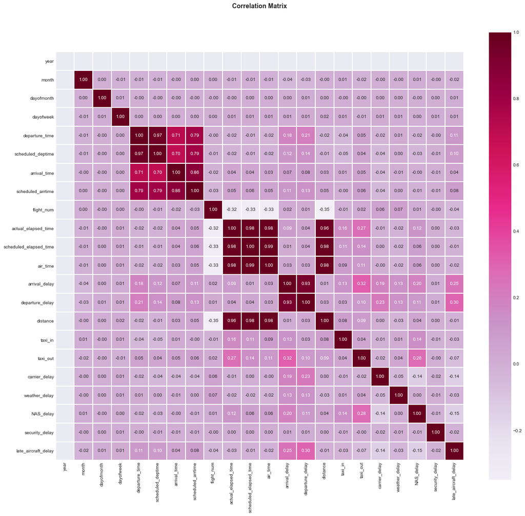

```python
# correlation matrix

plt.figure(figsize=(20, 18))

sns.heatmap(airline_notcancelled.corr(), square=True, annot=True, fmt='.2f', cmap= 'PuRd', center=.3, linewidth=1, annot_kws={'fontsize': 10});

plt.title("Correlation Matrix", size=14, weight="bold", y = 1.1)

plt.show()
```

- `Distance` is highly correlated with `actual elapased time 96%` , `scheduled elapsed time 98%` and `air time 98%` and this makes a huge sense because the more the distance is the more the time you will spend in the air.
- `Arrival delay` is highly correlated with the `Departure delay 93%`, and this also makes sense because the flights that arrived delay most likely would departure delay.

### What is the relationship between the Distance and Actual Elapsed Time and Air Time ?

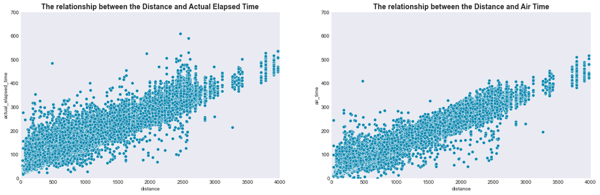

```python
fig, (ax1, ax2) = plt.subplots(1, 2, figsize=(20, 6))

# plot 1

ax1.set_title('The relationship between the Distance and Actual Elapsed Time', fontsize= 14, weight = 'bold')
sns.scatterplot(data=airline_samp, x='distance', y='actual_elapsed_time', color=blue, ax =ax1 )
ax1.set_xlim(0,4000)
ax1.set_ylim(0,700)

# plot 2

ax2.set_title('The relationship between the Distance and Air Time', fontsize= 14, weight = 'bold')
sns.scatterplot(data=airline_samp, x='distance', y='air_time', color=blue, ax =ax2)
ax2.set_xlim(0,4000)
ax2.set_ylim(0,700)


plt.show()
```

- There is a `Positive correlation` which means if the distance increases both the actual elapsed time and air time will increase.

### What is the relationship between the arrival delay and departure delay ?

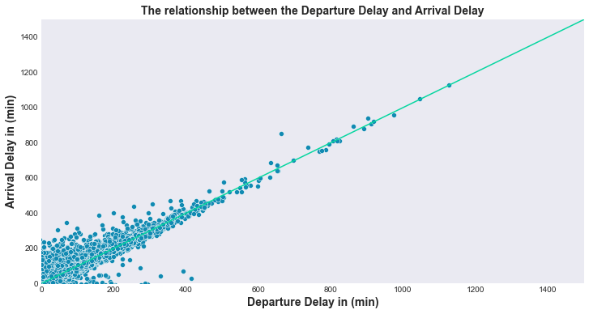

```python
plt.figure(figsize=(12,6))

# plotting the scatter plot
g = sns.scatterplot(data=airline_samp, x='departure_delay', y='arrival_delay', color=blue)

# add the identity line, so we need to know the max scores of all scores:
line = max(max(df['departure_delay']) , max(df['arrival_delay']))
plt.plot([0,line], [0,line], color = green)

g.set_xlim(0,1500)
g.set_ylim(0,1500)

#axes labels and title
plt.xlabel('Departure Delay in (min)',fontsize = 14, weight = "bold")
plt.ylabel('Arrival Delay in (min)', fontsize = 14, weight = "bold")
plt.title('The relationship between the Departure Delay and Arrival Delay', fontsize= 14, weight = 'bold')

plt.show()
```

> There is a positive correlation, if the flight going off late absolutely it would arrive late.

### Is there a relationship between the Distance and the Arrival Delay ?

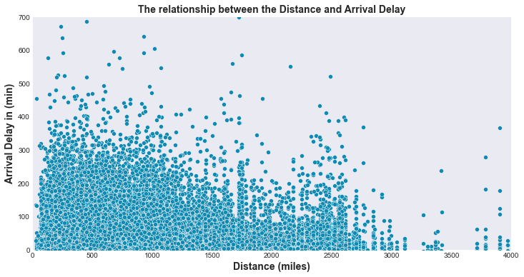

```python
plt.figure(figsize=(12,6))

# plotting the scatter plot

g = sns.scatterplot(data=airline_samp, x='distance', y='arrival_delay', color=blue)


g.set_xlim(0,4000)
g.set_ylim(0,700)

#axes labels and title
plt.xlabel('Distance (miles)',fontsize = 14, weight = "bold")
plt.ylabel('Arrival Delay in (min)', fontsize = 14, weight = "bold")
plt.title('The relationship between the Distance and Arrival Delay', fontsize= 14, weight = 'bold')

plt.show()
```

```python
airline_samp[['distance', 'arrival_delay']].corr()
```

|  | distance | arrival_delay |
| --- | --- | --- |
| distance | 1.000000 | 0.003378 |
| arrival_delay | 0.003378 | 1.000000 |

### What is the carrier with most delayed flights ?

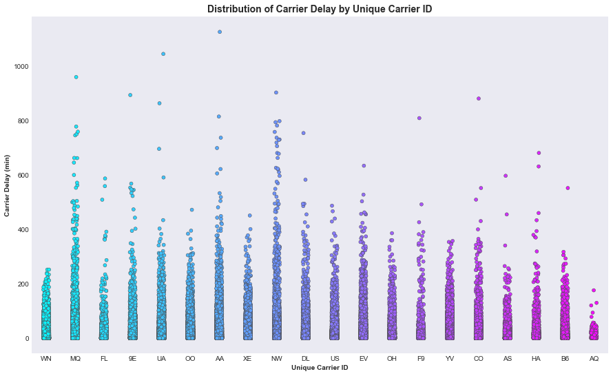

```python
plt.figure(figsize=[15, 9])
# plot
sns.stripplot(data=airline_notcancelled, x='unique_carrier', y='carrier_delay',
              dodge=True, linewidth=0.5, palette='cool');

# title, lables & legend
plt.title("Distribution of Carrier Delay by Unique Carrier ID", fontsize = 14, weight = "bold")
plt.ylabel('Carrier Delay (min)', fontsize = 10, weight = "bold")
plt.xlabel('Unique Carrier ID', fontsize = 10, weight = "bold")

plt.show()
```

```python
carrier.query("Code == 'NW'")
```

|  | Code | Description |
| --- | --- | --- |
| 920 | NW | Northwest Airlines Inc. |

> `Northwest Airlines` has the most delayed flights followed by `American Eagel Airlines` and `American Airlines`

### Is there a relationship between the Month, Day of month and Day of week with Arrival Delay ?

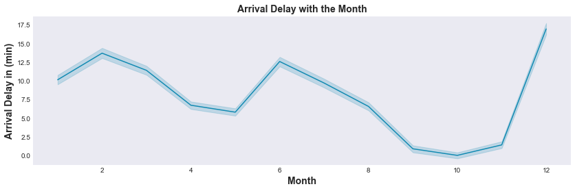

```python
plt.figure(figsize=(14,4))

sns.lineplot(data=airline_notcancelled, x= 'month', y='arrival_delay',color = blue )

# the labels and title
plt.xlabel('Month', fontsize= 14, weight = 'bold')
plt.ylabel('Arrival Delay in (min)', fontsize= 14, weight = 'bold')
plt.title('Arrival Delay with the Month', fontsize= 14, weight = 'bold')

plt.show()
```

- From December to March there is high arrival delay maybe because of the bad weather these months.
- June is too high .
- But from september to November the delay is too small.

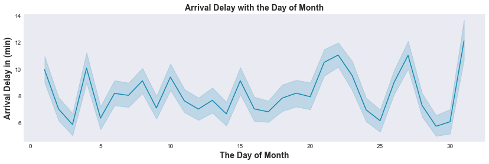

```python
plt.figure(figsize=(14,4))

sns.lineplot(data=airline_notcancelled, x= 'dayofmonth', y='arrival_delay',color = blue )

# the labels and title
plt.xlabel('The Day of Month', fontsize= 14, weight = 'bold')
plt.ylabel('Arrival Delay in (min)', fontsize= 14, weight = 'bold')
plt.title('Arrival Delay with the Day of Month',  fontsize= 14, weight = 'bold')

plt.show()
```

> I see the ups and downs with all the days of the month , so there is not a relationship here.

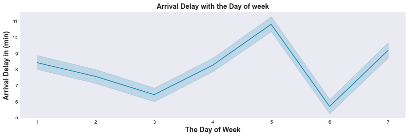

```python
plt.figure(figsize=(14,4))

sns.lineplot(data=airline_notcancelled, x= 'dayofweek', y='arrival_delay',color = blue)

# the labels and title
plt.xlabel('The Day of Week', fontsize= 14, weight = 'bold')
plt.ylabel('Arrival Delay in (min)', fontsize= 14, weight = 'bold')
plt.title('Arrival Delay with the Day of week' ,fontsize= 14, weight = 'bold')

plt.show()
```

## Multivariate Exploration

> Create plots of three or more variables to investigate the data even further.

### What is the cancellation reasons for American Airlines and American Eagel Airlines ?

```python
# make subset for the cancelletion flights

subset = airline_cancelled.query('(unique_carrier == "AA") | (unique_carrier == "MQ")')
```

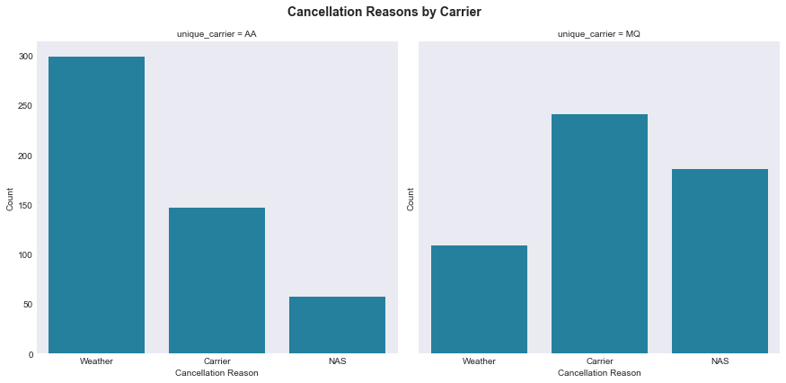

```python
# getting order

order = subset['cancellation_code'].value_counts().index

# plotting

g = sns.FacetGrid(data=subset, col='unique_carrier', col_wrap=5, height=6)
g.map(sns.countplot, 'cancellation_code', order= order)

# rename the columns
#The Cancellation Code : reason for cancellation (A = carrier, B = weather, C = NAS, D = security)
g.set_xticklabels(['Weather', 'Carrier', 'NAS'])



# axis label and title
g.set(xlabel='Cancellation Reason', ylabel='Count')
plt.suptitle('Cancellation Reasons by Carrier', fontsize = 14, weight = "bold", x=0.20)

plt.tight_layout();
plt.show()
```

### What is the cancellation for American Airlines and American Eagel Airlines per month?

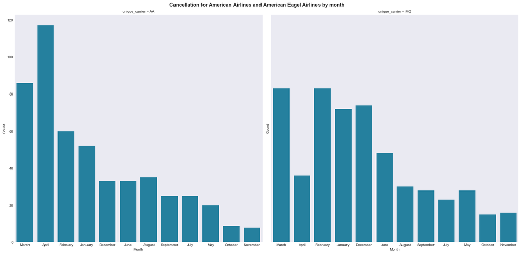

```python
# getting order

order = subset['month_name'].value_counts().index

# plotting

g = sns.FacetGrid(data=subset, col='unique_carrier', col_wrap=5, height=10)
g.map(sns.countplot, 'month_name', order= order)

# axis label and title
g.set(xlabel='Month', ylabel='Count')
plt.suptitle('Cancellation for American Airlines and American Eagel Airlines by month', fontsize = 14, weight = "bold", x=0.20)

plt.tight_layout();
plt.show()
```

### Does the Distance affect the Arrival Delay for the Carrier ?

```python
# make subset for the Delay flights

subset2 = airline_notcancelled.query('(unique_carrier == "NW") | (unique_carrier == "AA") | (unique_carrier == "MQ")')

# these three carrier what I found the most delayed flights happend in 2008
```

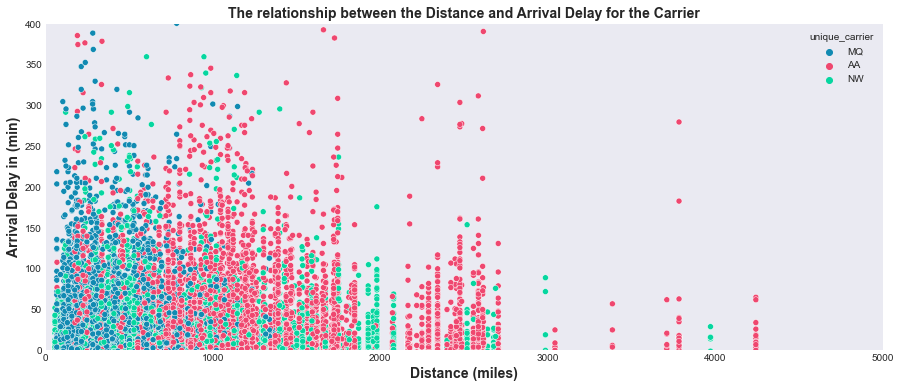

```python
plt.figure(figsize = (15,6))

# plotting the scatter plot
g =sns.scatterplot(data = subset2 ,  x = 'distance', y = 'arrival_delay', hue = 'unique_carrier' )

# putting the x and y lim
g.set_xlim(0,5000)
g.set_ylim(0, 400)

# #axes labels and title
plt.xlabel('Distance (miles)',fontsize = 14, weight = "bold")
plt.ylabel('Arrival Delay in (min)', fontsize = 14, weight = "bold")
plt.title('The relationship between the Distance and Arrival Delay for the Carrier', fontsize= 14, weight = 'bold')

plt.show()
```

> More Arrival delay happened in short Distance espcially with `MQ Airlines`

### Delayed flights for American Airlines and American Eagel Airlines per month:

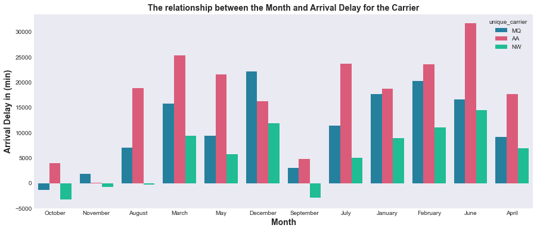

```python
plt.figure(figsize = (15,6))

#plot
sns.barplot(x="month_name", y="arrival_delay", data=subset2, estimator=sum, ci=None,  hue='unique_carrier');

#axes labels and title
plt.xlabel('Month',fontsize = 14, weight = "bold")
plt.ylabel('Arrival Delay in (min)', fontsize = 14, weight = "bold")
plt.title('The relationship between the Month and Arrival Delay for the Carrier', fontsize= 14, weight = 'bold')

plt.show()
```

> I don't see something special here its almost the same as cancelled fligts.

# Conclusions